# Weather file decomposition

Mike Wood

24 November 2016

# Abstract

Our work is about testing buildings for overheating in a more efficient and useful way.

The current methods are limited. Buildings are usually only testing with one year’s-worth of weather data. This is a problem because a) one year is rarely enough of a test to give a building all the different type of heatwave that it might encounter in its lifetime and b) because simulating the weather over a whole year is not necessary (in most cases you don’t need to simulation winter, spring and autumn to capture all of the overheating events).

Our work aims to address both the problems. First we use a simple technique to extract the hot weather events using data from 100s of simulations to detect the areas of weather files that contain significant heatwaves. Second, we then rate each of these heatwaves according to their duration and severity (based on their effect on buildings).

Based on these results, we must be very careful about how we design weather files to test our buildings. We have shown that the current methods do not give the full picture. Our research has shown a potential soluation for addressing this problem. Clearly, further work is therefore required.

# Introduction

## Testing buildings with weather files

Testing building is a complicated process. One of the main things that you need to do is test for overheating. However, since differnet types of buildings overheat differently and we don’t know what type of weather events a building might experience, we have a problem. How big should the overheating events be? What constitutes ‘bigness’? Should we test buildings the same way in Newcastle as we test them in London. And how do we define a local climate? Climates are changing all the time, so you cannot know for certain what the climate might be like in a given location - let alone guess what the individual overheating events might be.

There are a lot of questions to answer - and there are equally as many ways to answer them. HOwever, we need to start somewhere. In this paper, we have decided to look at the very bottom of the question tree… How do we define a heatwave?

We have also recently shown that it is **very** difficult to assess whether a building is overheating internally, since, again there are so many different overheating measurement methods to choose from. Eames has looking into this in his recent paper for the *Winsor Conference*. Among other things, the paper looks at extreme internal overheating events. He looked for heatwaves with severities that occured every 1:7 years and every 1:21 years. However, instead of rating the severity by the *external* temperature, he rated them using the *internal* temperature. The results were interesting.

Eames chose years that had a 1:7 year event in them, based on the internal overheating metric. However, the year chosen was dependent on the overheating metric chosen. In other words, the overheating metric you choose will affect how ‘severe’ a heat wave appears.

In some ways this is to be expected because different overheating metrics measure different things.

What we need is a good method for finding overheating events that trigger a particular metric. This would solve two problems:

- It would enable ‘redundant’ sections of the weather file to be removed, thereby reducing the computational burden in testing buildings for overheating.
- If we know how much an overheating event will trigger a particular metric, then we can analyse past and future weather to identify how often a particular event is likely to occur. We can then use weather generation models (such as the UKCP09 weather generator) to make predictions of how many of these events are likely to occur in the future.

Once we have this information, we might have better tools for ‘stress testing’ buidlings designs for the events that they might encounter in the future. However, we first need some tools to identify these events so that this research can begin.

Our work is in three stages:

- identify the overheating criteria (as this will affect the overheating events selected - as we have already seen)
- find out when this overheating criteria is likely to be triggered in a given weather file
- rate the overheating events in each weather file according to their severity

## Related work

Papers to review:

- Reference: [1]
- Reference: [2]
- Reference: [3]
- Reference: [4]
- Reference: [5]
- Reference: [6]
- Reference: [7]

# Overheating definitions

CIBSE TM52 [8] was released in 2013 and introduces three overheating criteria:

1. The number of hours where the internal operative temperature is above the maximum acceptable temperature (H<sub>e</sub>)[^1]
2. The daily weighted exceedance (W<sub>e</sub>).
3. The maximum operative temperature (T<sub>upper</sub>)

These criteria are intended to minimise overheating over a broad range of possible overheating events.

## The derivation of $\Delta T$

H<sub>e</sub> stands for hours of exceendance, where the exceedance is measured by $\Delta T$, rounded to the nearest degree[^2]. The exceedance $\Delta T$ is the number of hours where the internal operative temperature T<sub>op</sub> is above the maximum acceptable temperature T<sub>comf</sub>. The internal operative temperature T<sub>op</sub>, is defined as:

$$T_{op} = \frac{T_a - T_r}{2}$$

Where $T_a$ is the mean air temperature and $T_r$ is the mean radiant temperature.

The difference between the maximum acceptable temperature and the operative temperature is defined as $\Delta T$, where:

$$\Delta T = T_{op} - T_{max}$$

Where $T_{max}$ is maximum acceptable internal temperature.

This equation requires a further definition, that of $T_{max}$.

$T_{max}$ is the definition of the maximum acceptable temperature. However, it has been shown that the ‘accpetable temperatue’ is dependent on recent external temperature trends. This is due to temperature adaptation. So, in order to define, $T_{max}$, the *running mean* temperature is used:

$$T_{max} = 0.33 T_{rm} + 21.8$$

The running mean T<sub>rm</sub> is defined as:

$$T_{rm} = (1-\alpha) T_{od-1} + \alpha T_{rm-1}$$

Where $T_{od-1}$ is the outdoor daily mean temperature for the previous day, $T_{rm-1}$ is the running mean temperature for the previous day and $\alpha$ is an empirically derived coefficient which typically takes the value 0.8.

These equations can be used to derive $\Delta T$ for each timestep. Once $\Delta T$ is known, the CIBSE criteria can then be calculated.

The hours of exceedance H<sub>e</sub> is defined as the number of hours where the $\Delta T$ is greater than 1 degree. H<sub>e</sub> should be less than 3% of occupied hours for the period between 1st May until the 31st September.

The second criteria is the daily weighted exceedance, W<sub>e</sub>. Although this is defined as the weighted exceedance, it best thought of as the cumulative exceedance. This is best explained visually (figure 1).

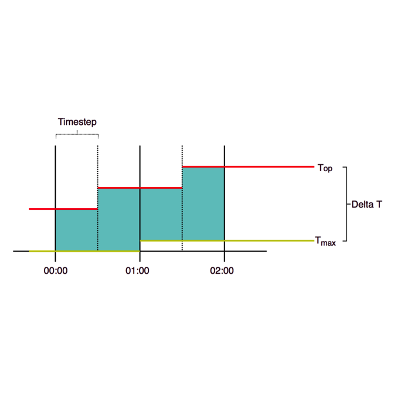

The third criteria is simple; the maximum value of $\Delta T$ should be no greater than 4.

# Method

## Analysis of the buildings

Our method is one of simple extraction. It runs the following process:

[figure not shown]

Delta T extraction process

Once we have stored the results, we can then compare them.

# Results

Set of Q-Q plots for values in the CIBSE criteria.

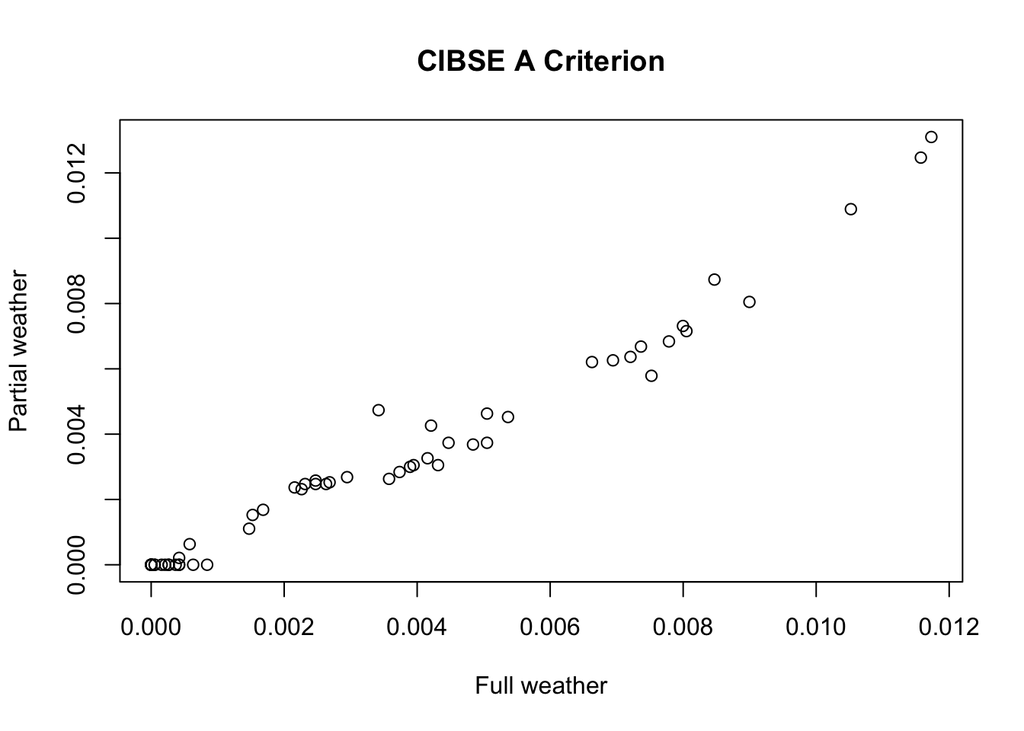

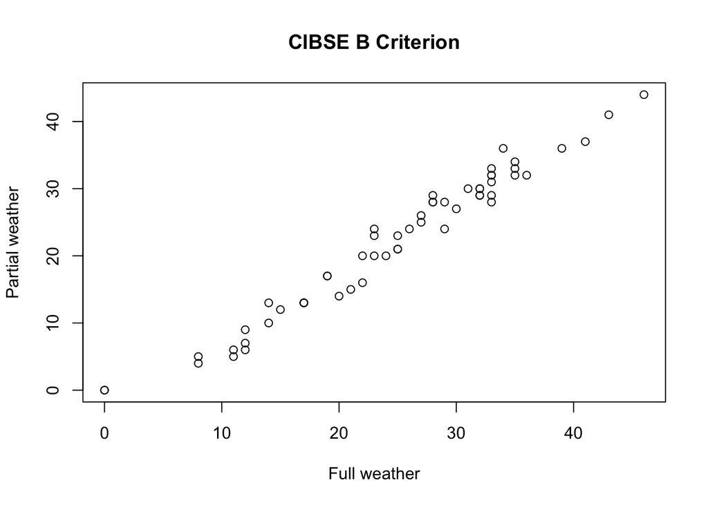

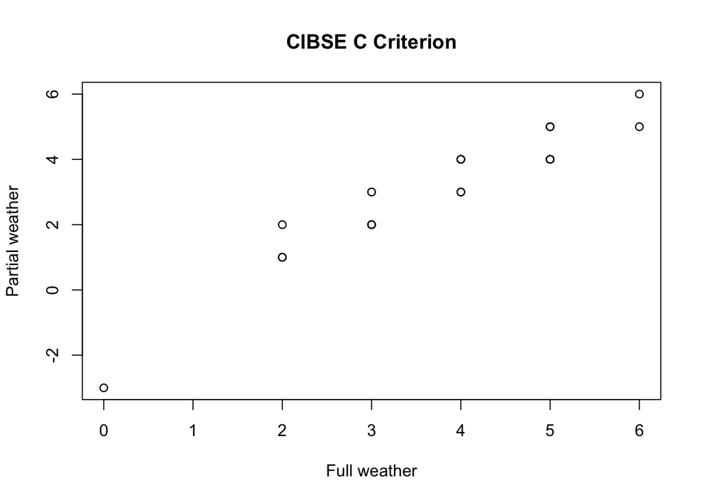

## Individual outputs

The plots below show three example plots for Belfast. The first shows the ‘trace’ of individual buildings. The lines in the trace show where $\Delta T>0$. The second shows the same results, but stacked. This allows the relative frequency that each hour is overheating for all buildings in the set.

The third graph shows the maximum weighted exceedance for a given day. (The year is indexed by hours so that it is easy to compare with the other two graphs.). This gives a measure of the severity of how much the heatwave affects all of the buildings.

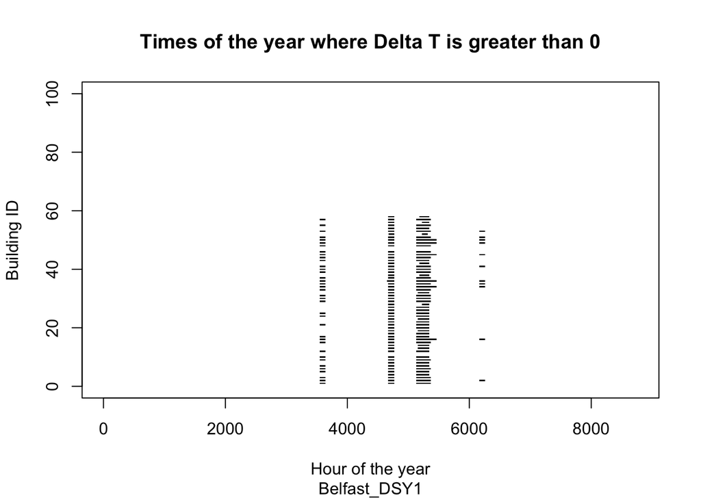

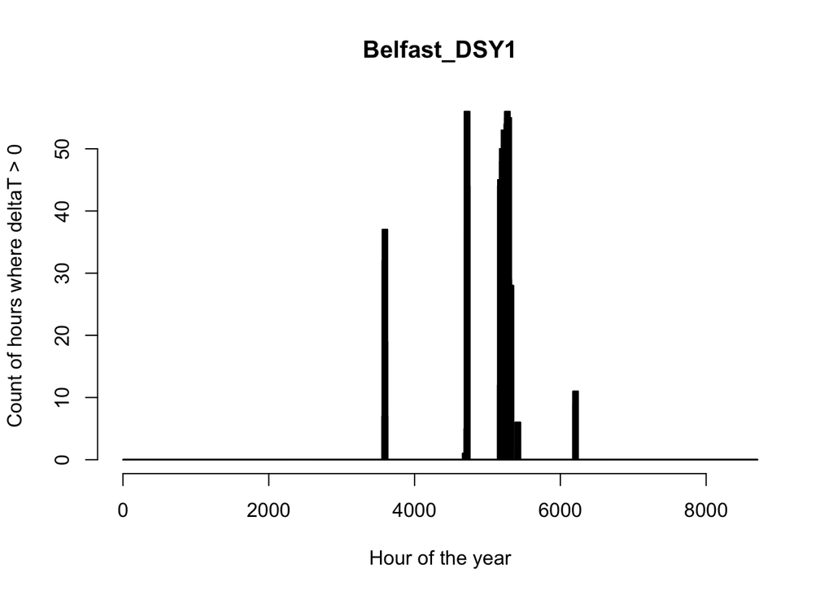

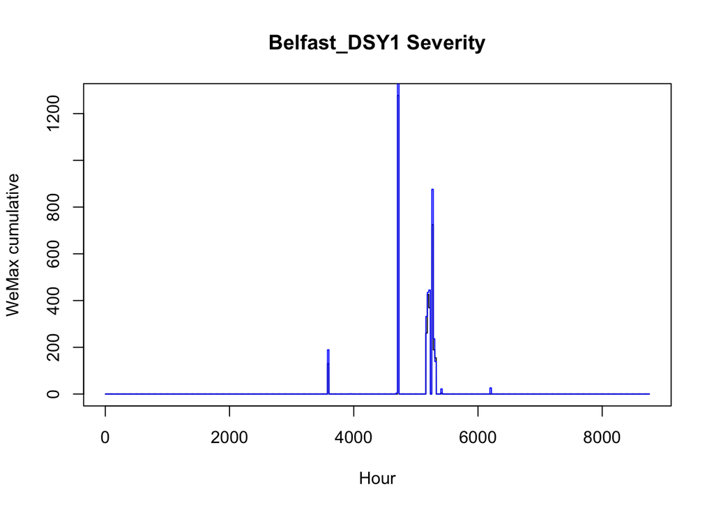

[1] G. Levermore and J. Parkinson, “Analyses and algorithms for new test reference years and design summer years for the uk,” *Building services engineering research and technology*, vol. 27, no. 4, pp. 311–325, 2006.

[2] M. E. Eames, “An update of the uk’s design summer years: Probabilistic design summer years for enhanced overheating risk analysis in building design,” *Building Services Engineering Research and Technology*, p. 0143624416631131, 2016.

[3] M. F. Jentsch, A. S. Bahaj, and P. A. James, “Climate change future proofing of buildings—Generation and assessment of building simulation weather files,” *Energy and Buildings*, vol. 40, no. 12, pp. 2148–2168, 2008.

[4] J. Hacker, R. Capon, and A. Mylona, *Use of climate change scenarios for building simulation: The cibse future weather years*. Chartered Institution of Building Services Engineers, 2009.

[5] D. Coley and T. Kershaw, “Changes in internal temperatures within the built environment as a response to a changing climate,” *Building and environment*, vol. 45, no. 1, pp. 89–93, 2010.

[6] S. Porritt, L. Shao, P. Cropper, and C. Goodier, “Adapting dwellings for heat waves,” *Sustainable Cities and Society*, vol. 1, no. 2, pp. 81–90, 2011.

[7] R. S. Kovats and L. E. Kristie, “Heatwaves and public health in europe,” *The European Journal of Public Health*, vol. 16, no. 6, pp. 592–599, 2006.

[8] F. Nicol, “The limits of thermal comfort: Avoiding overheating in european buildings: CIBSE tm52, 2013,” 2013.

[^1]: Where H<sub>e</sub> stands for *hours of exceedance*
[^2]: note that $\Delta T$ is measured on each timestep, rather than over a whole year, as H<sub>e</sub> is.